# pj1_report: HAPPY MOMENTS

yp2446

20th Sep 2018

I decide to break my report into 2 parts:

- 1. Basic explatory data analysis
- 2. Sentiment analysis

# Step1. Explatory Analysis

Firstly, given the already “washed” HAPPY MOMENT data which is ready for use up to the level sentiment analysis, I will simply perform some straightfoward exploratory analysis which shall give some intuitions other than those graphics in Rshiny ui.

### short glimpse of data

```
## Observations: 94,574
## Variables: 11
## $ wid                   <int> 2053, 2, 1936, 206, 45, 195, 740, 3, 483...
## $ original_hm           <chr> "I went on a successful date with someon...
## $ gender                <chr> "m", "m", "f", "f", "m", "m", "m", "m", ...
## $ marital               <chr> "single", "married", "married", "married...
## $ parenthood            <chr> "n", "y", "y", "n", "n", "n", "n", "n", ...
## $ reflection_period     <chr> "24h", "24h", "24h", "24h", "24h", "24h"...
## $ age                   <chr> "35", "29.0", "30", "28", "23", "30", "2...
## $ country               <chr> "USA", "IND", "USA", "OTHER", "IND", "US...
## $ ground_truth_category <chr> NA, NA, NA, "bonding", "leisure", NA, NA...
## $ text                  <chr> "successfully date sympathy connected", ...
## $ count                 <int> 4, 3, 3, 6, 2, 4, 4, 3, 5, 4, 7, 3, 3, 1...
```

## 1.1 Popular words by gender

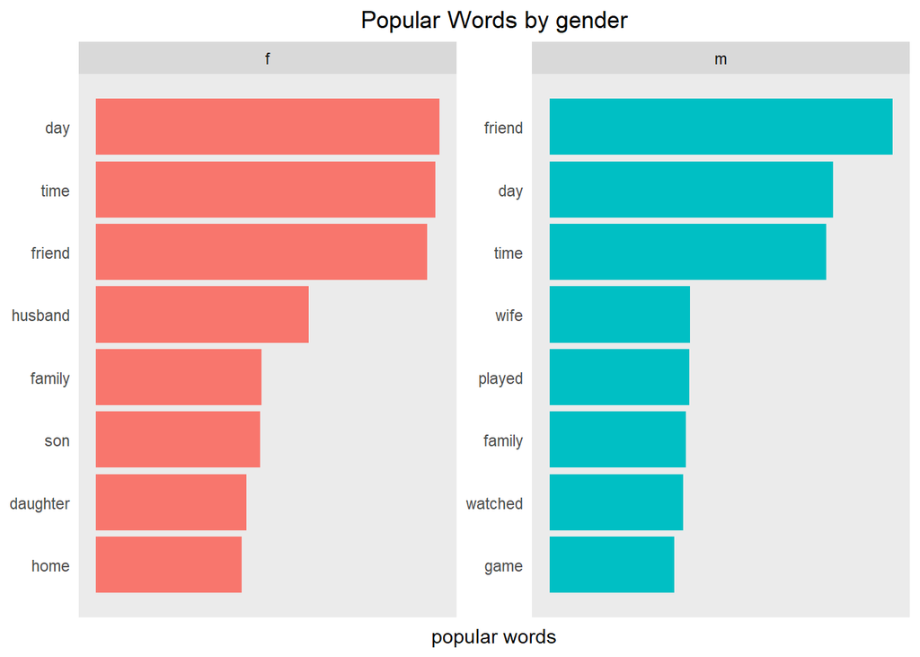

In chart “Comparison of Proportions” in the Rshiny UI, the marginal popularity of word’s distribution among genders is vague and fuzzy so I drew a graph that could deliver a closer look. What are the insights that you can gather from above? Well, though the dominant words of both men and women are day, time and friends, women tend to consider more of their offsprings – son and daughter – while male characters tend to watch TV or play games.

## 1.2 Sentence length distribution

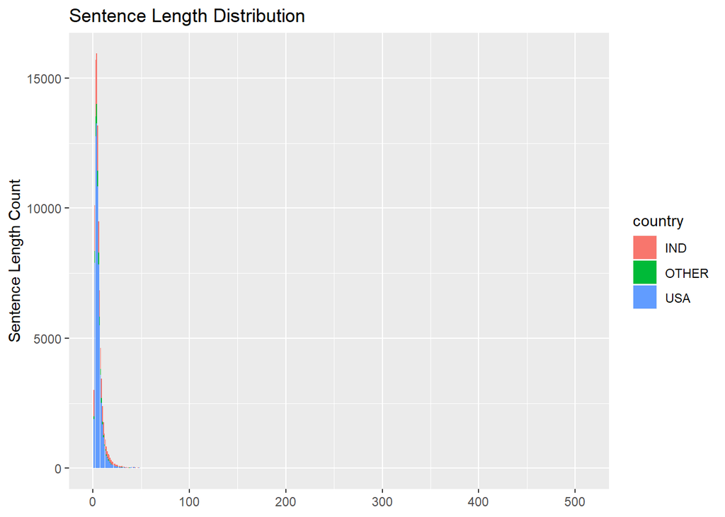

As we can see from the figure, the distribution is very fat-tailed, the max sentence length even reaches 509. The reason why there are so much outliers are some people just copied an essay as an answer of happy moment which read: *“This is the second essay in a two-part series about my journey to visit the Taj Mahal. Read the first part for the whole story…* so I decide to truncate the sentence length distribution.

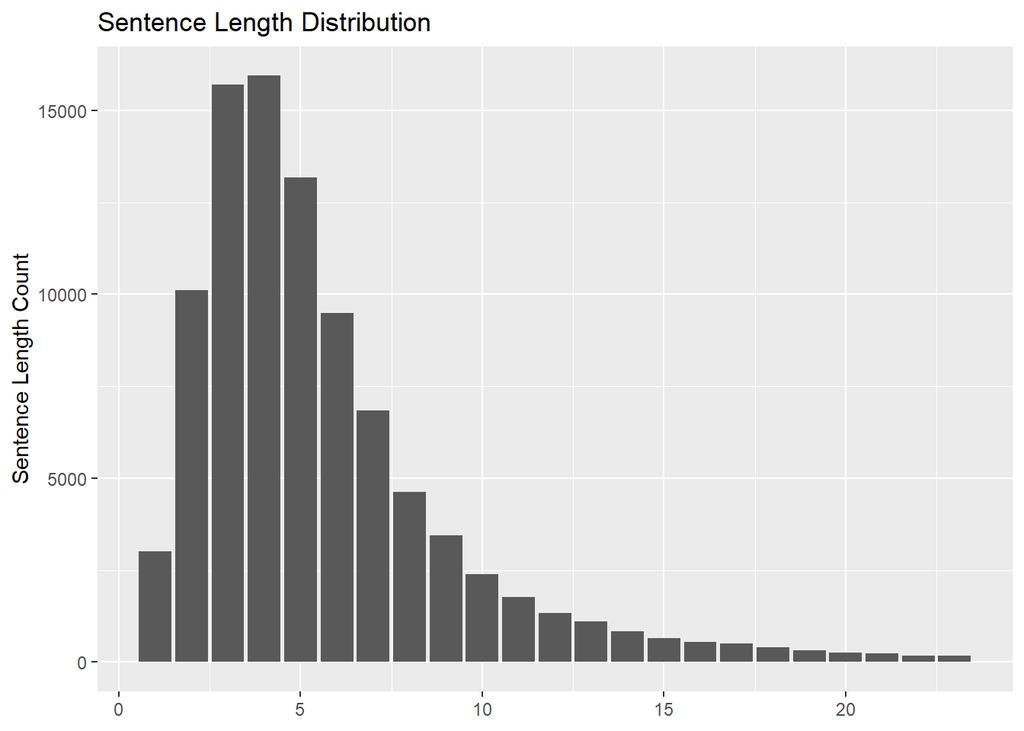

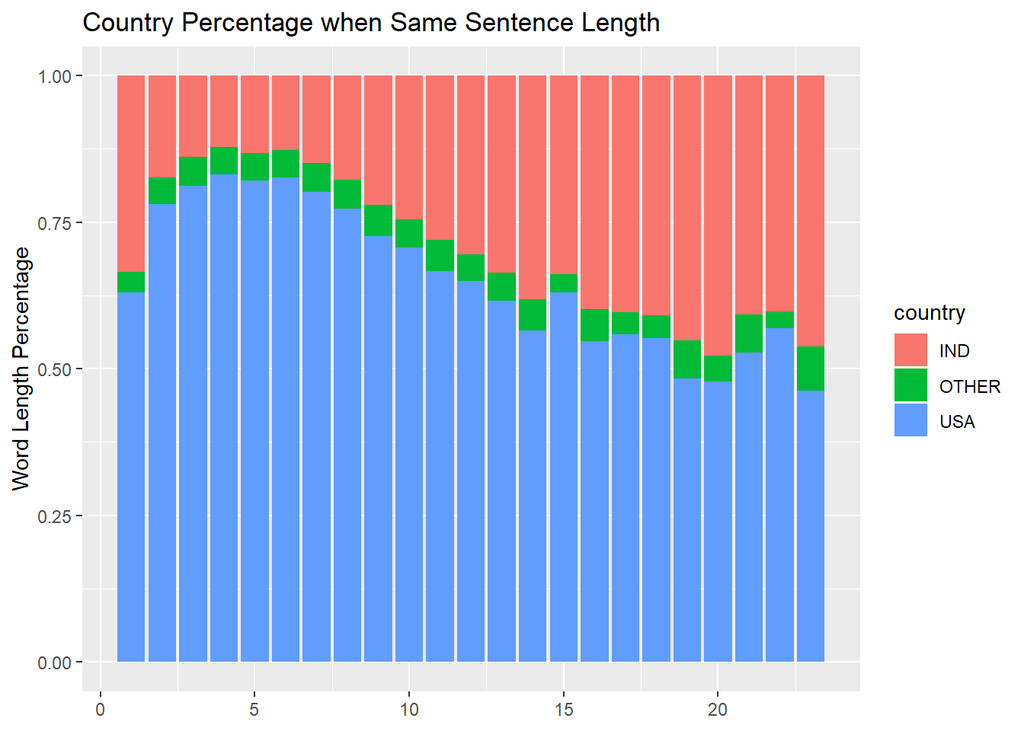

Now, the outlier problem is solved. Notice Indians are good at writing long sentences.

## 1.3 Lexical diversity

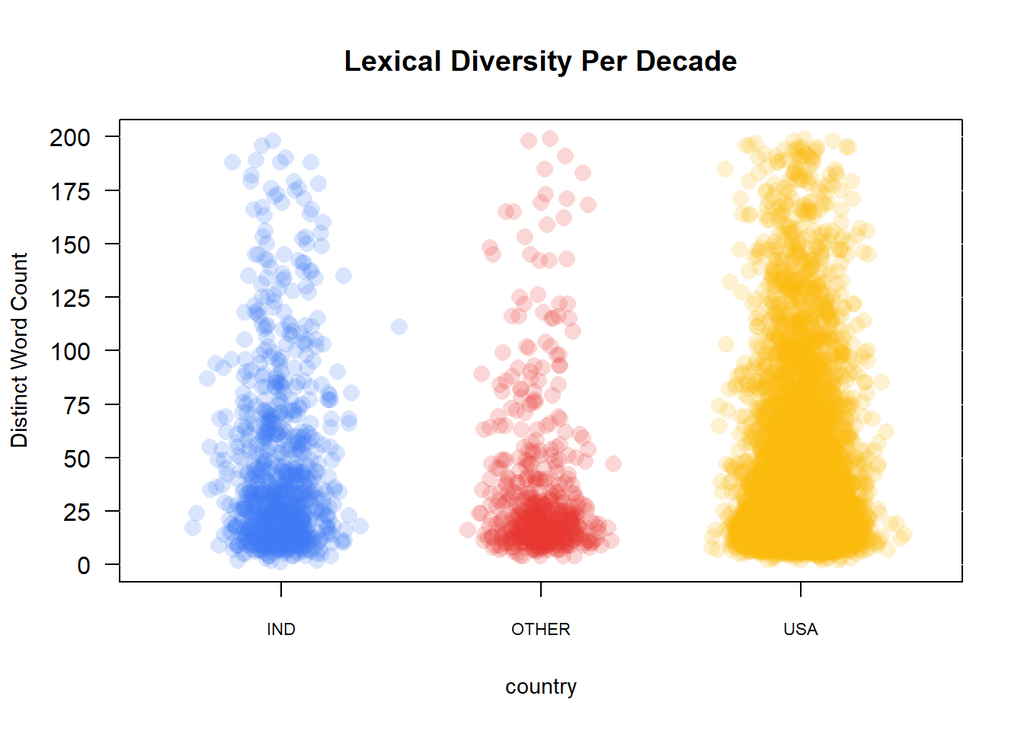

This pic conveys an intuition that though Americans tend to write short, they bear a larger lexical diversity than Indians. The avg.of lexical diversity is influnced by that “essay” outlier a lot thus I ignored it.

# Step2. Sentiment Analysis

## 2.1 Look up nrc lexicon

Total Word Counts Of nrc

| lexicon | words_in_lexicon | anger | anticipation | disgust | fear | joy | negative | positive | sadness | surprise | trust |
| --- | --- | --- | --- | --- | --- | --- | --- | --- | --- | --- | --- |
| nrc | 6468 | 1247 | 839 | 1058 | 1476 | 689 | 3324 | 2312 | 1191 | 534 | 1231 |

Lyrics Found In Lexicons

| lexicon | lex_match_words | words_in_hm | match_ratio |
| --- | --- | --- | --- |
| nrc | 2338 | 18812 | 0.1242824 |

In project’s archive, they have done sentiment analyse by using LIWC and VAD score. So I shall use nrc lexicon to conduct sentiment analyse. From above we know there are 6,468 words in nrc lexicon and distributed in 10 emotions. In the cleaned version of HAPPY DB, we have 2338 linked words out of 18812 unique words with nrc lexicon, taking up 12.4% of unique words.

## 2.2 Sentiment Analysis Bar Chart

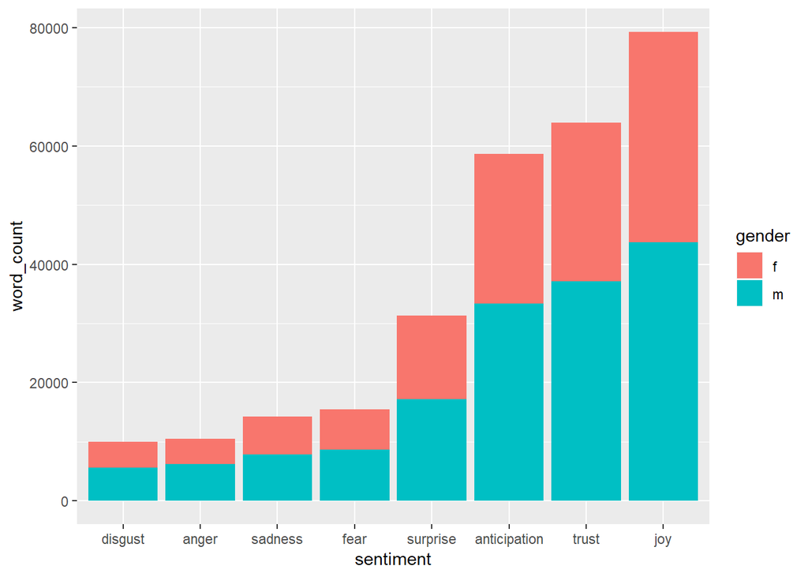

As we can see here, to most happy moment corpus, the nrc supports joy, trust, anticipation and surprise. It is in consistence with the convergency. what’s more, male covers more words than female, I think this is because men tend to use more moody words when writing while women tend to write more nouns to describe.